# Course Project

# Background

In this report the project data from accelerometers on the belt, forearm, arm, and dumbell of 6 participants is used to predict the manner in which they did an exercise. The participants did barbell lifts in 5 different ways, shown in the variable “classe” in the trainings set.  
The report describes:

- how the model was built
- how cross validation was used
- what the expected out of sample error is

Additionally the prediction model was used to predict 20 different test cases.

## 1. load library and data

```r
library(caret)
train <- read.csv("pml-training.csv", header=TRUE)
dim(train)
```

```
## [1] 19622   160
```

## 2. Filter the variables

In the dataset there are 160 variables, which are too much to use them all for the predictor. Hence, the data were first filtered, to get the important variables.

### 2.1 remove NA-columns

A clear prediction can only be done with enough data. Hence the columns with too much NAs were removed. Therefore, all columns were transformed to numeric and all variables with more than 50% NAs were removed. The classe variable will be added again later.

```r
short.func <- function(col){length(na.omit(as.numeric(col)))}
applylist <- apply(train, 2, short.func)
train.cut <- train[, -which(applylist<(nrow(train)/2))]
dim(train.cut)
```

```
## [1] 19622    56
```

### 2.2 remove all date and name columns

The prediction should be dependent on the motion, so all variables which have nothing to do with motion (e.g. names or day) were removed.

```r
colnames(train.cut)[c(1:4)]
```

```
## [1] "X"                    "raw_timestamp_part_1" "raw_timestamp_part_2"
## [4] "num_window"
```

```r
train.cut <- train.cut[,-c(1:4)]

dim(train.cut)
```

```
## [1] 19622    52
```

### 2.3 remove variables with nearly zero variance

Variables with near zero Variance are not useful for a predictor. Hence these should be estimated and removed. Therefore nearZeroVar was used, but there were no variables with near zero variance.

```r
nsv <- nearZeroVar(train.cut, saveMetrics = TRUE)
nsv
```

```
##                      freqRatio percentUnique zeroVar   nzv
## roll_belt             1.101904     6.7781062   FALSE FALSE
## pitch_belt            1.036082     9.3772296   FALSE FALSE
## yaw_belt              1.058480     9.9734991   FALSE FALSE
## total_accel_belt      1.063160     0.1477933   FALSE FALSE
## gyros_belt_x          1.058651     0.7134849   FALSE FALSE
## gyros_belt_y          1.144000     0.3516461   FALSE FALSE
## gyros_belt_z          1.066214     0.8612782   FALSE FALSE
## accel_belt_x          1.055412     0.8357966   FALSE FALSE
## accel_belt_y          1.113725     0.7287738   FALSE FALSE
## accel_belt_z          1.078767     1.5237998   FALSE FALSE
## magnet_belt_x         1.090141     1.6664968   FALSE FALSE
## magnet_belt_y         1.099688     1.5187035   FALSE FALSE
## magnet_belt_z         1.006369     2.3290184   FALSE FALSE
## roll_arm             52.338462    13.5256345   FALSE FALSE
## pitch_arm            87.256410    15.7323412   FALSE FALSE
## yaw_arm              33.029126    14.6570176   FALSE FALSE
## total_accel_arm       1.024526     0.3363572   FALSE FALSE
## gyros_arm_x           1.015504     3.2769341   FALSE FALSE
## gyros_arm_y           1.454369     1.9162165   FALSE FALSE
## gyros_arm_z           1.110687     1.2638875   FALSE FALSE
## accel_arm_x           1.017341     3.9598410   FALSE FALSE
## accel_arm_y           1.140187     2.7367241   FALSE FALSE
## accel_arm_z           1.128000     4.0362858   FALSE FALSE
## magnet_arm_x          1.000000     6.8239731   FALSE FALSE
## magnet_arm_y          1.056818     4.4439914   FALSE FALSE
## magnet_arm_z          1.036364     6.4468454   FALSE FALSE
## roll_dumbbell         1.022388    84.2065029   FALSE FALSE
## pitch_dumbbell        2.277372    81.7449801   FALSE FALSE
## yaw_dumbbell          1.132231    83.4828254   FALSE FALSE
## total_accel_dumbbell  1.072634     0.2191418   FALSE FALSE
## gyros_dumbbell_x      1.003268     1.2282132   FALSE FALSE
## gyros_dumbbell_y      1.264957     1.4167771   FALSE FALSE
## gyros_dumbbell_z      1.060100     1.0498420   FALSE FALSE
## accel_dumbbell_x      1.018018     2.1659362   FALSE FALSE
## accel_dumbbell_y      1.053061     2.3748853   FALSE FALSE
## accel_dumbbell_z      1.133333     2.0894914   FALSE FALSE
## magnet_dumbbell_x     1.098266     5.7486495   FALSE FALSE
## magnet_dumbbell_y     1.197740     4.3012945   FALSE FALSE
## magnet_dumbbell_z     1.020833     3.4451126   FALSE FALSE
## roll_forearm         11.589286    11.0895933   FALSE FALSE
## pitch_forearm        65.983051    14.8557741   FALSE FALSE
## yaw_forearm          15.322835    10.1467740   FALSE FALSE
## total_accel_forearm   1.128928     0.3567424   FALSE FALSE
## gyros_forearm_x       1.059273     1.5187035   FALSE FALSE
## gyros_forearm_y       1.036554     3.7763735   FALSE FALSE
## gyros_forearm_z       1.122917     1.5645704   FALSE FALSE
## accel_forearm_x       1.126437     4.0464784   FALSE FALSE
## accel_forearm_y       1.059406     5.1116094   FALSE FALSE
## accel_forearm_z       1.006250     2.9558659   FALSE FALSE
## magnet_forearm_x      1.012346     7.7667924   FALSE FALSE
## magnet_forearm_y      1.246914     9.5403119   FALSE FALSE
## magnet_forearm_z      1.000000     8.5771073   FALSE FALSE
```

### 2.4 remove correlated variables

If variables are correlated, you can remove one of these, because it won’t give you additional information. This was done with cor and findCorrelation. A threshold of 75% corellation was choosen.

```r
corel <- findCorrelation(cor(train.cut), cutoff = .75)
corel # 20 variables are correlated with others and can be removed
```

```
##  [1] 10  1  9 22  4 36  8  2 37 35 38 21 34 23 25 12 48 19 46 31
```

```r
train.cut <- train.cut[,-corel]

dim(train.cut)
```

```
## [1] 19622    32
```

### 2.5 calculation of variable importance

A first training was done to estimate the variable importance. Due to the long estimation time, this step was saved before knitting and know is only loaded. For prediction, random Forest was used. A threshold of 35% was used, to exclude variables, which are not that important.

```r
train.cut$classe <- train$classe

# modFit <- train(classe~.,data=train.cut, method="rf")
# save(modFit, file = "predictiondata.20.03.Rdata")

load("predictiondata.20.03.Rdata")

mostimp <- varImp(modFit)
train.fin <- train.cut[,c(row.names(mostimp$importance)[which(mostimp$importance>35)], "classe")]

dim(train.fin)
```

```
## [1] 19622    12
```

## 3. Training with cross validation

```r
set.seed(123)
inTrain = createDataPartition(train.fin$classe, p=3/4)[[1]]
cross.train= train.fin[inTrain,]
cross.val = train.fin[-inTrain,]
```

As above, the training was done with random forest and the training was done before knitting, due to the long estimation time, and know is only loaded.

```r
set.seed(62433)
# modFit2 <- train(cross.train$classe~.,data=cross.train, method="rf", trControl=trainControl(method="cv"), number=5)
# save(modFit, modFit2, file = "predictiondata.20.03.Rdata")

load("predictiondata.20.03.Rdata")

modFit2
```

```
## Random Forest
##
## 14718 samples
##    11 predictor
##     5 classes: 'A', 'B', 'C', 'D', 'E'
##
## No pre-processing
## Resampling: Cross-Validated (10 fold)
##
## Summary of sample sizes: 13247, 13247, 13247, 13245, 13247, 13246, ...
##
## Resampling results across tuning parameters:
##
##   mtry  Accuracy   Kappa      Accuracy SD  Kappa SD
##    2    0.9796856  0.9743053  0.004641698  0.005872860
##    6    0.9792773  0.9737921  0.004497222  0.005686685
##   11    0.9722796  0.9649453  0.004253998  0.005380108
##
## Accuracy was used to select the optimal model using  the largest value.
## The final value used for the model was mtry = 2.
```

The used model has an accuracy of 0.98, shown at the first point in the following plot.

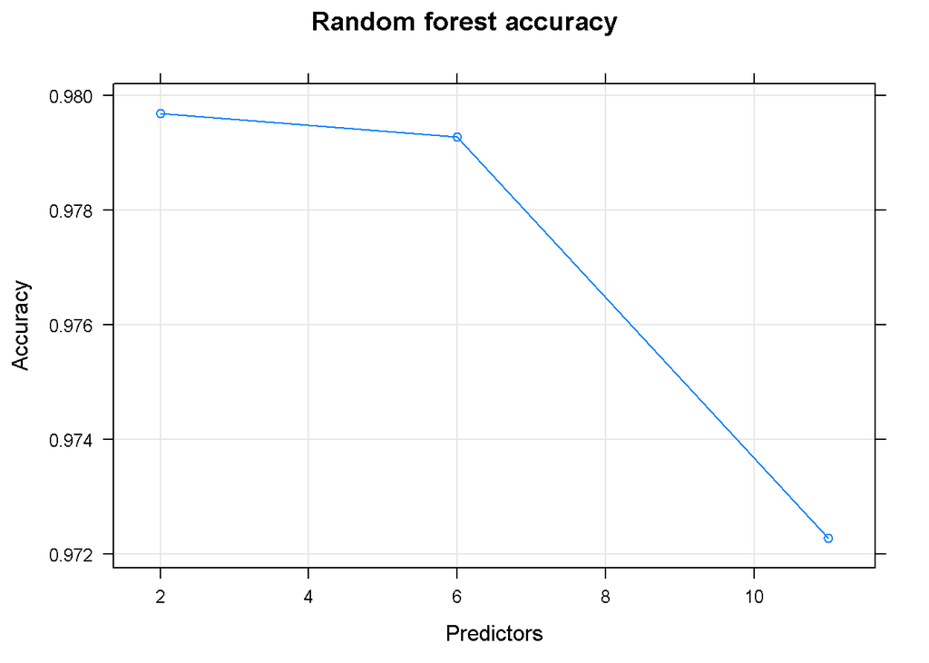

```r
plot(modFit2, main = "Random forest accuracy", xlab = "Predictors",
    ylab = "Accuracy")
```

## 4. Out of sample error

The in sample error is the error, you get on the same data set you used to build your predictor. This is 1-accuracy, which is 0.02 in this model.

The out of sample error is the error you get on a new data set. The out of sample error is always bigger than the in sample error, due to overfitting.

The error could be estimated by predicting the classes for the validation set and calculating the accuracy. By calculating 1-accuracy, you get the error.

```r
pld1 <- predict(modFit2, cross.val)

cM <- confusionMatrix(predict(modFit2, newdata=cross.val), cross.val$classe)

cM
```

```
## Confusion Matrix and Statistics
##
##           Reference
## Prediction    A    B    C    D    E
##          A 1385   14    0    2    0
##          B    3  920   14    2    0
##          C    1   11  815   22    0
##          D    4    4   26  777    2
##          E    2    0    0    1  899
##
## Overall Statistics
##
##                Accuracy : 0.978
##                  95% CI : (0.9735, 0.9819)
##     No Information Rate : 0.2845
##     P-Value [Acc > NIR] : < 2.2e-16
##
##                   Kappa : 0.9721
##  Mcnemar's Test P-Value : NA
##
## Statistics by Class:
##
##                      Class: A Class: B Class: C Class: D Class: E
## Sensitivity            0.9928   0.9694   0.9532   0.9664   0.9978
## Specificity            0.9954   0.9952   0.9916   0.9912   0.9993
## Pos Pred Value         0.9886   0.9798   0.9600   0.9557   0.9967
## Neg Pred Value         0.9971   0.9927   0.9901   0.9934   0.9995
## Prevalence             0.2845   0.1935   0.1743   0.1639   0.1837
## Detection Rate         0.2824   0.1876   0.1662   0.1584   0.1833
## Detection Prevalence   0.2857   0.1915   0.1731   0.1658   0.1839
## Balanced Accuracy      0.9941   0.9823   0.9724   0.9788   0.9985
```

```r
ose <- 1-cM$overall[[1]]

paste("Out of sample error: ", round(ose, digits=2), sep="")
```

```
## [1] "Out of sample error: 0.02"
```

The out of sample error is very small with 0.02, and nearly the same as the in sample error.

## 5. Prediction: apply your machine learning algorithm to the 20 test cases

The prediction was applied to the 20 test cases.

```r
testcases <-  read.csv("pml-testing.csv", header=TRUE)

pld2 <- predict(modFit2, testcases)

pld2
```

```
##  [1] B A B A A E D B A A B C B A E E A B B B
## Levels: A B C D E
```